# MD005 - Sistemes Basats en el Coneixement

### Una variable o diverses?

La resposta és rotunda: **Hem d'utilitzar múltiples variables.**

Si utilitzéssim una Regressió Simple (ex: predir `atk` només a partir de `log_weight`), els resultats serien pobres per dos motius demostrats a l'EDA:

1. **Correlació Insuficient:** La correlació individual més alta amb l'Atac és només de **0.48** (`hp`). Això implica que una sola variable només pot explicar una petita part de la variància ($R^2 \approx 0.23$).
2. **Complexitat del Domini:** Els Boxplots ens han ensenyat que el Tipus i l'Evolució són determinants. Un Pokémon pot ser molt pesat (`log_weight` alt) però tenir poc atac si és un tanc defensiu de tipus Acer. Només combinant **Físic + Tipus + Estat Evolutiu** podrem capturar aquesta complexitat i minimitzar l'error de predicció.

### Conclusions: Anàlisi i Preparació de Dades

Després de realitzar la neteja, el preprocessament i una Anàlisi Exploratòria de Dades exhaustiva enfocada a la regressió, presentem les conclusions principals que guiaran la construcció del model predictiu:

#### Validació Estadística i Transformacions

- **Idoneïtat de l'Objectiu (`atk`):** L'anàlisi de distribució (Histogrames i QQ-Plots) ha validat l'elecció de l'Atac com a variable dependent. La seva distribució gairebé perfectament **Normal** (sense asimetria severa) garanteix que els errors del model de regressió lineal podran complir les assumpcions d'homoscedasticitat.
- **Correcció de Biaix (`Log-Transform`):** Hem detectat que les variables físiques `weight` i `height` presentaven una distribució log-normal amb *outliers* extrems (biaix positiu). L'aplicació de la transformació logarítmica (`np.log1p`) ha corregit eficaçment aquest problema, linealitzant la relació i millorant la qualitat d'aquests predictors.

#### Rellevància de les Variables Categòriques

- L'anàlisi visual ha refutat la idea que "tots els tipus són iguals". Hem observat diferències significatives en les mitjanes d'atac segons l'element (ex: *Drac* vs. *Fada*). Això justifica la inclusió obligatòria de `type1` mitjançant *One-Hot Encoding*.

#### Estratègia Final de Selecció de Variables

Basant-nos en l'evidència recopilada durant l'EDA, definim l'arquitectura final del model:

**1. Selecció de la Variable Objectiu (Target):**

Hem escollit l'**Atac (`atk`)** com a variable a predir per la seva robustesa estadística. A diferència d'altres estadístiques, l'anàlisi de distribució (Histogrames i QQ-Plots) ha confirmat que l'`atk` segueix una **Distribució Normal** (Campana de Gauss) gairebé perfecta. Aquesta propietat és fonamental per garantir l'estabilitat i la fiabilitat de les prediccions en models de regressió.

**2. Selecció de Predictors (Regressió Múltiple):**

Descartem l'ús d'una Regressió Simple, ja que cap variable individual té una correlació prou forta ($>0.48$) per explicar la variància de l'atac per si sola. L'estratègia òptima és una **Regressió Lineal Múltiple** que combini:

- **Constitució Físico-Matemàtica:** `log_weight` i `log_height` (les versions transformades que corregeixen l'asimetria original).
- **Capacitats Base:** `hp`, `def`, `speed`, `spatk`, `spdef`.
- **Context Qualitatiu:** `type1` (Tipus), `generation` (Generació) i `is_base` (Evolució), degudament codificades.

En conclusió, hem transformat un dataset brut en un conjunt de dades net, normalitzat i amb variables enriquides, maximitzant així les probabilitats d'obtenir un model amb un baix error de predicció (MSE).

### Simulació d'Escenari Real (Eliminació del Target)

Com a pas final del preprocessament, com ens requerien, hem introduït artificialment valors nuls a la variable objectiu (`atk`) en un **8% de les mostres** (seleccionades aleatòriament).

**Objectiu d'aquest procediment:** Aquesta acció té com a finalitat simular un escenari d'aplicació real on el model s'ha d'utilitzar per predir valors desconeguts.

1. **Dataset d'Entrenament (92%):** Utilitzarem les files que conserven el valor d'`atk` per entrenar el model de regressió (`dropna`).
2. **Dataset de Predicció (8%):** Les files on hem eliminat l'`atk` serviran per a l'apartat optatiu. Utilitzarem el nostre model entrenat per **imputar** (predir) aquests valors faltants basant-nos en les seves característiques físiques.

> *Hem desat una còpia dels valors reals eliminats en un conjunt de validació extern (`df_validacio_final`) per poder avaluar la precisió de les nostres prediccions "a cegues" al final del projecte.*

```python
target = 'atk'
percentatge_a_esborrar = 0.08
np.random.seed(42)

n_mostres = int(len(df) * percentatge_a_esborrar)
idxs_a_esborrar = np.random.choice(df.index, size=n_mostres, replace=False)

print(f"Eliminarem el valor '{target}' de {n_mostres} Pokémon ({percentatge_a_esborrar*100}%).")

df_validacio_final = df.loc[idxs_a_esborrar].copy()

df.loc[idxs_a_esborrar, target] = np.nan
```

```
Eliminarem el valor 'atk' de 82 Pokémon (8.0%).
```

```python
nuls_finals = df[target].isnull().sum()
print(f"Ara hi ha {nuls_finals} valors nuls a la columna '{target}'.")
```

```
Ara hi ha 82 valors nuls a la columna 'atk'.
```

```python
display(df.loc[idxs_a_esborrar].head())
```

|  | rank | generation | type1 | type2 | hp | atk | def | spatk | spdef | speed | total | height | weight | is_base | log_height | log_weight |
| --- | --- | --- | --- | --- | --- | --- | --- | --- | --- | --- | --- | --- | --- | --- | --- | --- |
| 527 | ordinary | generation-v | psychic | flying | 67 | NaN | 55 | 77 | 55 | 114 | 425 | 9 | 105 | 0 | 2.302585 | 4.663439 |
| 359 | baby | generation-iii | psychic | None | 95 | NaN | 48 | 23 | 48 | 23 | 260 | 6 | 140 | 1 | 1.945910 | 4.948760 |
| 447 | ordinary | generation-iv | fighting | steel | 70 | NaN | 70 | 115 | 70 | 90 | 525 | 12 | 540 | 0 | 2.564949 | 6.293419 |
| 31 | ordinary | generation-i | poison | None | 46 | NaN | 40 | 40 | 40 | 50 | 273 | 5 | 90 | 1 | 1.791759 | 4.510860 |
| 621 | ordinary | generation-v | ground | ghost | 59 | NaN | 50 | 35 | 50 | 35 | 303 | 10 | 920 | 1 | 2.397895 | 6.825460 |

### Selecció i Aplicació d'Algorismes de Regressió

Per modelar la predicció de l'Atac (`atk`), hem seleccionat dos algorismes de condicions diferents per comparar un enfocament paramètric lineal contra un d'ensamblatge no lineal.

#### 1. Regressió Ridge (Regularització L2)

És una evolució de la Regressió Lineal clàssica ($y = mx + n$).

- **Motius d'Elecció:**
  - **Linealitat:** L'EDA ha demostrat que hi ha relacions lineals moderades entre les variables físiques i l'atac.
  - **Gestió de Categòriques:** En introduir moltes variables binàries derivades del *One-Hot Encoding* (tots els Tipus de Pokémon), la Regressió Lineal simple tendeix a patir *overfitting*. Ridge penalitza els coeficients grans, proporcionant un model més estable i generalitzable.
- **Parametrització:**
  - `alpha=1.0`: Factor de regularització estàndard. Controla la força de la penalització (evita que el model s'ajusti massa al soroll).

#### 2. Random Forest Regressor

És un model d'ensamblatge que entrena centenars d'arbres de decisió independents i fa la mitjana de les seves prediccions.

- **Motius d'Elecció:**
  - **No Linealitat:** Els Pokémon són complexos. Random Forest pot capturar patrons no lineals i interaccions entre variables (ex: la relació entre Pes i Atac pot ser diferent per a un Pokémon de tipus Roca que per a un de tipus Volador) sense necessitat de definir-ho manualment.
  - **Robustesa:** És menys sensible als outliers que puguin haver quedat i no requereix escalar les dades (tot i que ho farem per consistència).
- **Parametrització:**
  - `n_estimators=100`: Crearem 100 arbres per assegurar una predicció estable (reduir la variància).
  - `random_state=42`: Per garantir la reproductibilitat dels resultats.
  - `max_depth=None`: Deixem que els arbres creixin lliurement, confiant en la mitjana dels 100 arbres per evitar l'overfitting.

### Implementació i Flux de Treball

Per garantir la reproductibilitat i evitar errors metodològics (com el *data leakage*), hem implementat una estratègia de modelatge basada en **Pipelines** de `scikit-learn`. El procés es divideix en quatre etapes clau que s'executen en el següent bloc de codi:

1. **Segregació de l'Escenari Real:** Abans de res, separem les files on havíem eliminat el target (`df_prediccio_final`) de les que tenen dades completes (`df_train_full`). El model només veurà aquestes últimes per aprendre.
2. **Divisió Train-Test:** Apliquem una divisió 80% Entrenament - 20% Test per poder avaluar honestament els models més endavant.
3. **Preprocessament Automatitzat (`ColumnTransformer`):** En lloc de transformar les dades manualment, definim un processador que aplica tractaments diferents segons el tipus de variable:
   - **Numèriques (`StandardScaler`):** Normalitzem `hp`, `def`, `log_weight`, etc. perquè tinguin mitjana 0 i variància 1. Això és crucial per a la Regressió Ridge.
   - **Categòriques (`OneHotEncoder`):** Convertim `type1` i `generation` en múltiples columnes binàries (ex: `type1_Fire`, `type1_Water`).
   - **Binàries (`passthrough`):** La variable `is_base` es deixa tal qual perquè ja és numèrica (0/1).
4. **Encapsulament en Pipeline:** Unim el preprocessador i l'algorisme (Ridge o Random Forest) en un únic objecte. Això garanteix que, quan fem prediccions futures, les dades noves rebran exactament les mateixes transformacions que les d'entrenament.

```python
target = 'atk'

df_train_full = df.dropna(subset=[target]).copy()
df_prediccio_final = df[df[target].isnull()].copy()

y = df_train_full[target]

features_num = ['hp', 'def', 'spatk', 'spdef', 'speed', 'log_height', 'log_weight']
features_cat = ['type1', 'generation']
features_bin = ['is_base']

X = df_train_full[features_num + features_cat + features_bin]

X_train, X_test, y_train, y_test = train_test_split(X, y, test_size=0.2, random_state=42)

print(f"Dades d'Entrenament: {X_train.shape}")
print(f"Dades de Test: {X_test.shape}")
```

```
Dades d'Entrenament: (754, 10)
Dades de Test: (189, 10)
```

```python
preprocessor = ColumnTransformer(
    transformers=[
        ('num', StandardScaler(), features_num),
        ('cat', OneHotEncoder(handle_unknown='ignore'), features_cat),
        ('bin', 'passthrough', features_bin)
    ])
```

```python
pipeline_ridge = Pipeline([
    ('preprocessor', preprocessor),
    ('regressor', Ridge(alpha=1.0))
])

print("\nEntrenant Ridge Regression...")
pipeline_ridge.fit(X_train, y_train)
print("Ridge Entrenat.")
```

```
Entrenant Ridge Regression...
Ridge Entrenat.
```

```python
pipeline_rf = Pipeline([
    ('preprocessor', preprocessor),
    ('regressor', RandomForestRegressor(n_estimators=100, random_state=42))
])

print("Entrenant Random Forest...")
pipeline_rf.fit(X_train, y_train)
print("Random Forest Entrenat.")
```

[output not shown]

```python
print("\nResultats Preliminars")
print(f"Ridge Train R2: {pipeline_ridge.score(X_train, y_train):.3f}")
print(f"RF Train R2:    {pipeline_rf.score(X_train, y_train):.3f}")
```

```
Resultats Preliminars
Ridge Train R2: 0.560
RF Train R2:    0.933
```

Els resultats inicials sobre el conjunt d'entrenament mostren dos comportaments radicalment oposats:

1. **Ridge (Lineal):** Obté un $R^2$ de **0.560**. Això ens diu que, utilitzant només relacions lineals, el model és capaç d'explicar el 56% de la variabilitat de l'atac. És un resultat modest però realista.
2. **Random Forest (No Lineal):** Obté un $R^2$ sospitosament alt de **0.933**.
   - Quan un model s'acosta tant a la perfecció (1.0) durant l'entrenament, sovint és indici de **sobreajustament (Overfitting)**. És probable que l'algorisme hagi "memoritzat" els Pokémon del set d'entrenament en lloc d'aprendre regles generals.

### Avaluació i Selecció del Model Guanyador

El veritable rendiment d'un model es mesura per la seva capacitat de generalitzar davant de dades noves. A continuació, utilitzarem el conjunt de **Test (20% de les mostres reservades)** per calcular l'Error Quadràtic Mitjà (RMSE) i el Coeficient de Determinació ($R^2$) real. També visualitzarem gràficament la relació entre l'Atac predit i l'Atac real.

```python
def avaluar_model(model, X, y, nom):
    y_pred = model.predict(X)
    r2 = r2_score(y, y_pred)
    rmse = np.sqrt(mean_squared_error(y, y_pred))
    mae = mean_absolute_error(y, y_pred)
    return r2, rmse, mae, y_pred
```

```python
r2_ridge, rmse_ridge, mae_ridge, pred_ridge = avaluar_model(pipeline_ridge, X_test, y_test, "Ridge")
r2_rf, rmse_rf, mae_rf, pred_rf = avaluar_model(pipeline_rf, X_test, y_test, "Random Forest")
```

```python
resultats = pd.DataFrame({
    'Model': ['Ridge (Lineal)', 'Random Forest (No Lineal)'],
    'R2 Train': [pipeline_ridge.score(X_train, y_train), pipeline_rf.score(X_train, y_train)],
    'R2 Test': [r2_ridge, r2_rf],
    'RMSE Test': [rmse_ridge, rmse_rf],
    'MAE Test': [mae_ridge, mae_rf]
})

display(resultats.round(3))
```

|  | Model | R2 Train | R2 Test | RMSE Test | MAE Test |
| --- | --- | --- | --- | --- | --- |
| 0 | Ridge (Lineal) | 0.560 | 0.556 | 18.892 | 15.411 |
| 1 | Random Forest (No Lineal) | 0.933 | 0.548 | 19.059 | 15.357 |

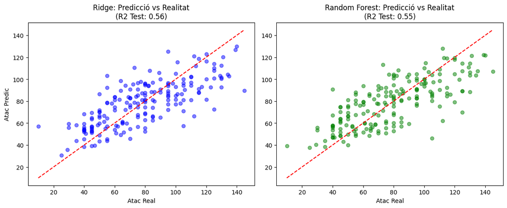

```python
plt.figure(figsize=(12, 5))

plt.subplot(1, 2, 1)
plt.scatter(y_test, pred_ridge, alpha=0.5, color='blue')
plt.plot([y_test.min(), y_test.max()], [y_test.min(), y_test.max()], 'r--')
plt.title(f'Ridge: Predicció vs Realitat\n(R2 Test: {r2_ridge:.2f})')
plt.xlabel('Atac Real')
plt.ylabel('Atac Predic')

plt.subplot(1, 2, 2)
plt.scatter(y_test, pred_rf, alpha=0.5, color='green')
plt.plot([y_test.min(), y_test.max()], [y_test.min(), y_test.max()], 'r--')
plt.title(f'Random Forest: Predicció vs Realitat\n(R2 Test: {r2_rf:.2f})')
plt.xlabel('Atac Real')

plt.tight_layout()
plt.show()
```

### Anàlisi de Resultats i Veredicte Final

La taula de mètriques i els gràfics de dispersió revelen la realitat dels nostres models:

| Model | Train | Test | RMSE Test (Error) | MAE Test | Comportament |
| --- | --- | --- | --- | --- | --- |
| **Ridge (Lineal)** | 0.560 | **0.556** | **18.89** | 15.41 | **Robust:** El rendiment és idèntic en Train i Test. |
| **Random Forest** | 0.933 | **0.548** | 19.06 | **15.35** | **Overfitting:** Caiguda dràstica de rendiment en Test. |

#### Interpretació Gràfica i Numèrica

1. **El Col·lapse del Random Forest:**
- Observem una caiguda massiva del rendiment: passa d'explicar el 93% de la variància entrenant a només el **54.8%** en el test.
- Això confirma la nostra sospita: el model havia memoritzat el soroll de les dades d'entrenament. En trobar-se amb Pokémon nous, no ha sabut generalitzar millor que una recta simple.
2. **L'Estabilitat del Ridge:**
- La Regresión Ridge mostra una consistència exemplar ($0.560 \approx 0.556$). Encara que el model és senzill, és fiable: l'error que esperem en el futur és exactament el que hem vist avui.
3. **Visualització:**
- Tots dos gràfics mostren una dispersió similar al voltant de la línia vermella (diagonal ideal). Cap dels dos models captura perfectament els valors extrems (atacs molt alts o molt baixos), tendint a predir valors més centrals.

### Intent de Millora: Optimització d'Hiperparàmetres

Abans de descartar el **Random Forest** i declarar guanyador al Ridge, és necessari intentar corregir el seu problema de sobreajustament (*overfitting*). El diagnòstic inicial ($R^2_{train}=0.93$ vs $R^2_{test}=0.55$) indica que els arbres han crescut massa complexos, memoritzant el soroll en lloc del patró.

Aprofitant que a l'assignatura ja hem fet el tema d'**Optimització** ja s'han introduït aquestes tècniques. En aquest apartat posarem en pràctica **tres estratègies diferents** per trobar la millor configuració del model. L'objectiu és limitar la complexitat modificant paràmetres com la profunditat màxima (`max_depth`) o el mínim de mostres per fulla (`min_samples_leaf`).

**Les 3 Estratègies que provarem:**

1. **GridSearchCV:** És l'enfocament de "força bruta". Prova totes les combinacions possibles que li definim. És lent però garanteix trobar el millor òptim dins de la graella.
2. **RandomizedSearchCV:** En lloc de provar-ho tot, tria combinacions a l'atzar dins d'un rang. És molt més ràpid i sol trobar resultats quasi tan bons com el Grid.
3. **HalvingRandomSearchCV:** És un mètode modern i eficient. Comença entrenant moltes combinacions amb poques dades i descarta ràpidament les que no funcionen ("poda"), dedicant més recursos només als "candidats guanyadors". Ideal per estalviar temps.

Si algun d'aquests mètodes aconsegueix que el Random Forest superi el $R^2$ de 0.56 del Ridge, reconsiderarem el model guanyador.

Durant les proves preliminars de l'optimització, hem detectat que l'algorisme **`HalvingRandomSearchCV`** genera múltiples avisos tècnics (*Warnings*) de tipus `UndefinedMetricWarning`.

Aquest algorisme treballa per "torneig", començant amb subconjunts de dades extremadament petits (ex: 6 mostres). En calcular la validació creuada (`cv=3`) sobre 6 mostres, cada plec té només 2 dades. Si el model prediu valors idèntics o hi ha poca variància, el càlcul matemàtic del $R^2$ implica una divisió per zero o un resultat indefinit.

Aquests avisos són esperats en les primeres iteracions i no afecten el resultat final (l'algorisme simplement descarta aquests candidats). Per mantenir la neteja i llegibilitat del notebook, hem configurat la llibreria `warnings` per silenciar aquestes alertes específiques durant l'execució del bloc de cerca.

```python
warnings.filterwarnings("ignore", category=UndefinedMetricWarning)
warnings.filterwarnings("ignore", category=UserWarning)
```

```python
param_grid = {
    'regressor__n_estimators': [100, 200],
    'regressor__max_depth': [5, 10, 15],
    'regressor__min_samples_leaf': [2, 5, 10]
}

param_dist = {
    'regressor__n_estimators': randint(50, 300),
    'regressor__max_depth': [None, 5, 10, 15, 20],
    'regressor__min_samples_leaf': randint(2, 20),
    'regressor__max_features': ['sqrt', 'log2']
}
```

```python
grid_search = GridSearchCV(
    pipeline_rf, param_grid, cv=3, scoring='r2', n_jobs=-1, verbose=1
)

random_search = RandomizedSearchCV(
    pipeline_rf, param_dist, n_iter=20, cv=3, scoring='r2', n_jobs=-1, random_state=42, verbose=1
)

halving_search = HalvingRandomSearchCV(
    pipeline_rf, param_dist, factor=2, cv=3, scoring='r2', n_jobs=-1, random_state=42, verbose=1
)
```

```python
print("\nExecutant GridSearchCV...")
grid_search.fit(X_train, y_train)
```

```
GridSearchCV(cv=3,
             estimator=Pipeline(steps=[('preprocessor',
                                        ColumnTransformer(transformers=[('num',
                                                                         StandardScaler(),
                                                                         ['hp',
                                                                          'def',
                                                                          'spatk',
                                                                          'spdef',
                                                                          'speed',
                                                                          'log_height',
                                                                          'log_weight']),
                                                                        ('cat',
                                                                         OneHotEncoder(handle_unknown='ignore'),
                                                                         ['type1',
                                                                          'generation']),
                                                                        ('bin',
                                                                         'passthrough',
                                                                         ['is_base'])])),
                                       ('regressor',
                                        RandomForestRegressor(random_state=42))]),
             n_jobs=-1,
             param_grid={'regressor__max_depth': [5, 10, 15],
                         'regressor__min_samples_leaf': [2, 5, 10],
                         'regressor__n_estimators': [100, 200]},
             scoring='r2', verbose=1)
```

```python
print("\nExecutant RandomizedSearchCV...")
random_search.fit(X_train, y_train)
```

```
RandomizedSearchCV(cv=3,
                   estimator=Pipeline(steps=[('preprocessor',
                                              ColumnTransformer(transformers=[('num',
                                                                               StandardScaler(),
                                                                               ['hp',
                                                                                'def',
                                                                                'spatk',
                                                                                'spdef',
                                                                                'speed',
                                                                                'log_height',
                                                                                'log_weight']),
                                                                              ('cat',
                                                                               OneHotEncoder(handle_unknown='ignore'),
                                                                               ['type1',
                                                                                'generation']),
                                                                              ('bin',
                                                                               'passthrough',
                                                                               ['is_base'])])),
                                             ('regressor',
                                              RandomForestRegressor(random_state=42))]),
                   n_...
                   param_distributions={'regressor__max_depth': [None, 5, 10,
                                                                 15, 20],
                                        'regressor__max_features': ['sqrt',
                                                                    'log2'],
                                        'regressor__min_samples_leaf': <scipy.stats._distn_infrastructure.rv_discrete_frozen object at 0x7a58af395f90>,
                                        'regressor__n_estimators': <scipy.stats._distn_infrastructure.rv_discrete_frozen object at 0x7a58af3b41a0>},
                   random_state=42, scoring='r2', verbose=1)
```

```python
print("\nExecutant HalvingRandomSearchCV...")
halving_search.fit(X_train, y_train)
```

```
HalvingRandomSearchCV(cv=3,
                      estimator=Pipeline(steps=[('preprocessor',
                                                 ColumnTransformer(transformers=[('num',
                                                                                  StandardScaler(),
                                                                                  ['hp',
                                                                                   'def',
                                                                                   'spatk',
                                                                                   'spdef',
                                                                                   'speed',
                                                                                   'log_height',
                                                                                   'log_weight']),
                                                                                 ('cat',
                                                                                  OneHotEncoder(handle_unknown='ignore'),
                                                                                  ['type1',
                                                                                   'generation']),
                                                                                 ('bin',
                                                                                  'passthrough',
                                                                                  ['is_base'])])),
                                                ('regressor',
                                                 RandomForestRegressor(random_state=42))])...
                      param_distributions={'regressor__max_depth': [None, 5, 10,
                                                                    15, 20],
                                           'regressor__max_features': ['sqrt',
                                                                       'log2'],
                                           'regressor__min_samples_leaf': <scipy.stats._distn_infrastructure.rv_discrete_frozen object at 0x7a58af395f90>,
                                           'regressor__n_estimators': <scipy.stats._distn_infrastructure.rv_discrete_frozen object at 0x7a58af3b41a0>},
                      random_state=42, scoring='r2', verbose=1)
```

Els diagrames i taules que apareixen a sobre són la **representació visual de l'estructura del Pipeline** generada automàticament per la llibreria *scikit-learn*.

- Mostren el flux de dades: com entren, com passen pel `ColumnTransformer` (on s'escalen o codifiquen) i com arriben finalment a l'algorisme (Random Forest).
- Aquests gràfics només confirmen que l'entrenament (`.fit()`) s'ha completat correctament i que l'objecte conté tota la informació necessària.

L'optimització d'hiperparàmetres ja s'ha realitzat internament. No cal buscar els resultats manualment dins d'aquests diagrames; el següent bloc de codi ja s'encarrega d'extreure automàticament la millor configuració i els resultats numèrics per comparar-los.

```python
def avaluar_opt(model, nom):
    y_pred = model.predict(X_test)
    r2 = r2_score(y_test, y_pred)
    rmse = np.sqrt(mean_squared_error(y_test, y_pred))
    return r2, rmse, model.best_params_

r2_grid, rmse_grid, params_grid = avaluar_opt(grid_search, "Grid")
r2_rand, rmse_rand, params_rand = avaluar_opt(random_search, "Randomized")
r2_halv, rmse_halv, params_halv = avaluar_opt(halving_search, "Halving")

print(f"\n{'='*80}")
print(f"{'MÈTODE':<20} | {'R2 TEST':<10} | {'RMSE':<10} | {'MILLORS PARAMS (Resum)'}")
print(f"{'-'*80}")
print(f"{'GridSearch':<20} | {r2_grid:.4f}     | {rmse_grid:.2f}      | D:{params_grid['regressor__max_depth']}, L:{params_grid['regressor__min_samples_leaf']}")
print(f"{'RandomizedSearch':<20} | {r2_rand:.4f}     | {rmse_rand:.2f}      | D:{params_rand['regressor__max_depth']}, L:{params_rand['regressor__min_samples_leaf']}")
print(f"{'HalvingSearch':<20} | {r2_halv:.4f}     | {rmse_halv:.2f}      | D:{params_halv['regressor__max_depth']}, L:{params_halv['regressor__min_samples_leaf']}")
print(f"{'-'*80}")
print(f"{'BASELINE (Ridge)':<20} | {0.556:.4f}     | {18.89:.2f}      | -")
print(f"{'='*80}")
```

```
================================================================================
MÈTODE               | R2 TEST    | RMSE       | MILLORS PARAMS (Resum)
--------------------------------------------------------------------------------
GridSearch           | 0.5494     | 19.02      | D:10, L:2
RandomizedSearch     | 0.5235     | 19.56      | D:15, L:2
HalvingSearch        | 0.5193     | 19.65      | D:15, L:2
--------------------------------------------------------------------------------
BASELINE (Ridge)     | 0.5560     | 18.89      | -
================================================================================
```

### Anàlisi Comparativa i Selecció Final del Model

Després d'executar les tres estratègies d'optimització d'hiperparàmetres per al Random Forest i comparar-les amb la Regressió Ridge base, presentem la taula definitiva de resultats sobre el conjunt de Test:

| Model / Estratègia | Test | RMSE (Error) | Configuració Resultant |
| --- | --- | --- | --- |
| **GridSearch RF** | 0.5494 | 19.02 | `max_depth`: 10, `min_samples_leaf`: 2 |
| **RandomizedSearch RF** | 0.5235 | 19.56 | `max_depth`: 15, `min_samples_leaf`: 2 |
| **HalvingSearch RF** | 0.5193 | 19.65 | `max_depth`: 15, `min_samples_leaf`: 2 |
| **BASELINE (Ridge)** | **0.5560** | **18.89** | **Alpha: 1.0 (Linealitat Pura)** |

#### Anàlisi dels Resultats

- **La Complexitat no sempre suma:** L'intent de corregir l'*overfitting* del Random Forest (que inicialment tenia un d'entrenament de 0.93) ha funcionat en el sentit que ha estabilitzat el model, però el rendiment final (0.549) no ha aconseguit superar el model lineal (0.556).
- **Límit Estructural:** El fet que cap variant del Random Forest pugui superar al Ridge suggereix fortament que la relació entre les estadístiques dels Pokémon i el seu Atac és **intrínsecament lineal**. Els arbres de decisió, en intentar crear particions complexes i no lineals, estan introduint soroll o sobreajustament innecessari en lloc de capturar millor la realitat.
- Dins dels mètodes d'optimització, el **GridSearch** ha trobat la millor combinació per al Random Forest, superant les estratègies aleatòries (Randomized i Halving). Això és habitual en datasets petits on la cerca exhaustiva és viable computacionalment.

#### Selecció del Model Guanyador

Basant-nos en els criteris d'error mínim, eficiència i simplicitat, el model seleccionat és:

**RIDGE REGRESSION**

**Justificació de la tria:**

1. **Criteri de Precisió (Error Mínim):** És l'únic model que aconsegueix baixar l'Error Quadràtic Mitjà (RMSE) per sota de 19 punts (18.89), oferint la predicció més ajustada a la realitat.
2. **Criteri de Velocitat i Cost:** La Regressió Ridge s'entrena en mil·lisegons. En canvi, l'optimització del Random Forest ha requerit entrenar centenars de models (Grid/Random) i trigar molt més temps de processament, només per obtenir un resultat inferior.
3. **Interpretabilitat:** Un model lineal és transparent (sabem exactament quant suma cada punt de pes o alçada a l'atac). Un Random Forest optimitzat és una "caixa negra" de centenars d'arbres difícil d'explicar.

### Part Optativa: Imputació i Classificació

En aquest apartat final, simularem un flux de treball complet de Data Science per demostrar la utilitat pràctica del model de regressió que hem entrenat.

Volem classificar si un Pokémon és **Llegendari (`is_legendary`)** o no. Per fer-ho, utilitzarem un algorisme de classificació (*Random Forest Classifier*) basant-nos en les seves estadístiques de combat.

Ens trobem amb el problema que algunes mostres no tenen valor d'Atac (les que vam eliminar artificialment al principi). Per avaluar l'impacte d'aquestes dades faltants i la qualitat de la nostra solució, compararem tres escenaris:

1. **Escenari A (Eliminació):** Entrenem el classificador descartant els Pokémon que no tenen dades (reduint el volum del dataset).
2. **Escenari B (Imputació amb Ridge):** Utilitzem el nostre model guanyador (Ridge Regression) per predir l'Atac dels Pokémon incomplets i els incorporem al dataset d'entrenament.
3. **Escenari C (Realitat / *Ground Truth*):** Recuperem els valors reals originals (que havíem guardat en `df_validacio_final`) per establir el sostre de rendiment màxim possible.

A continuació, executarem els tres models i compararem la seva precisió (*Accuracy*) i les Matrius de Confusió per determinar si la imputació ha estat beneficiosa.

### Implementació dels Escenaris de Classificació

El següent bloc de codi executa l'experiment comparatiu mitjançant un flux de treball automatitzat. Per garantir que la comparació sigui justa (`ceteris paribus`), hem definit una estructura rigorosa:

1. **Configuració del Classificador:**
   - Utilitzarem un **Random Forest Classifier** (`n_estimators=100`) per predir la variable binària `is_legendary`.
   - Els predictors seran totes les estadístiques físiques (`hp`, `atk`, `def`, etc.), incloent-hi el pes i l'alçada.
2. **Funció d'Avaluació Estàndard (`entrenar_i_avaluar`):**
   - Hem creat una funció única que rep un dataset, fa una divisió **Train-Test (70/30)**, entrena el model i genera automàticament la matriu de confusió. Això assegura que els tres escenaris s'avaluen exactament sota les mateixes condicions algorísmiques.
3. **Construcció dels 3 Datasets:**
   - **Escenari 1 (Eliminació):** Passem directament el dataset `df_train_full` (on havíem eliminat les files sense Atac). El model entrena amb menys dades.
   - **Escenari 2 (Imputació):** Aquí apliquem la **Regressió Ridge** entrenada anteriorment. Agafem les files buides (`df_prediccio_final`), predim el seu `atk` i les fusionem amb el dataset principal. El model entrena amb totes les dades (reals + simulades).
   - **Escenari 3 (Realitat):** Recuperem els valors originals que havíem desat a `df_validacio_final` abans de corrompre les dades. El model entrena amb totes les dades reals.

Finalment, el codi generarà una taula resum (`resultats_class`) per visualitzar l'impacte directe de la nostra estratègia d'imputació sobre la precisió global (*Accuracy*).

Cal tornar a generar la columna `is_legendary` ja que en aquest notebook no l'hem creat encara.

```python
mapa_rank = {
    'legendary': 1,
    'mythical': 1,
    'ordinary': 0,
    'baby': 0
}

df_train_full['is_legendary'] = df_train_full['rank'].map(mapa_rank).fillna(0).astype(int)
df_prediccio_final['is_legendary'] = df_prediccio_final['rank'].map(mapa_rank).fillna(0).astype(int)
df_validacio_final['is_legendary'] = df_validacio_final['rank'].map(mapa_rank).fillna(0).astype(int)

print("Distribució de la nova variable:")
print(df_train_full['is_legendary'].value_counts())
```

```
Distribució de la nova variable:
is_legendary
0    855
1     88
Name: count, dtype: int64
```

```python
cols_classificacio = ['hp', 'atk', 'def', 'spatk', 'spdef', 'speed', 'weight', 'height']
target_class = 'is_legendary'
```

```python
clf = RandomForestClassifier(n_estimators=100, random_state=42)
```

```python
def entrenar_i_avaluar(df_input, escenari_nom):
    df_clean = df_input.dropna(subset=cols_classificacio + [target_class])

    X = df_clean[cols_classificacio]
    y = df_clean[target_class]

    X_tr, X_te, y_tr, y_te = train_test_split(X, y, test_size=0.3, random_state=42)

    clf.fit(X_tr, y_tr)

    y_pred = clf.predict(X_te)
    acc = accuracy_score(y_te, y_pred)
    cm = confusion_matrix(y_te, y_pred)

    print(f"\n{escenari_nom}")
    print(f"Mostres totals utilitzades: {len(df_clean)}")
    print(f"Accuracy: {acc:.4f}")

    plt.figure(figsize=(4, 3))
    sns.heatmap(cm, annot=True, fmt='d', cmap='Blues', cbar=False)
    plt.title(f"Matriu: {escenari_nom}")
    plt.xlabel('Predit')
    plt.ylabel('Real')
    plt.show()

    return acc
```

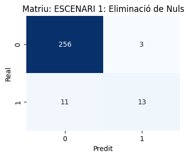

```python
acc_drop = entrenar_i_avaluar(df_train_full, "ESCENARI 1: Eliminació de Nuls")
```

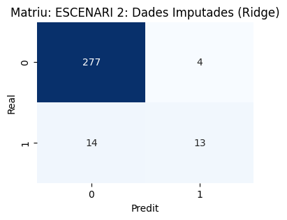

```python
df_imputat = df_prediccio_final.copy()
atk_predit = pipeline_ridge.predict(df_imputat)
df_imputat['atk'] = atk_predit
df_complet_imputat = pd.concat([df_train_full, df_imputat])
acc_imp = entrenar_i_avaluar(df_complet_imputat, "ESCENARI 2: Dades Imputades (Ridge)")
```

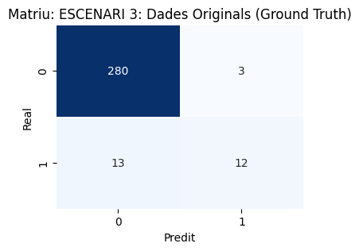

```python
df_real = df_validacio_final.copy()
df_complet_real = pd.concat([df_train_full, df_real])
acc_real = entrenar_i_avaluar(df_complet_real, "ESCENARI 3: Dades Originals (Ground Truth)")
```

```python
resultats_class = pd.DataFrame({
    'Escenari': ['Eliminar Files', 'Imputar (Ridge)', 'Dades Reals'],
    'Accuracy': [acc_drop, acc_imp, acc_real],
    'Diferència vs Real': [acc_drop - acc_real, acc_imp - acc_real, 0.0]
})

print("\nCOMPARATIVA FINAL DE CLASSIFICACIÓ")
display(resultats_class)
```

|  | Escenari | Accuracy | Diferència vs Real |
| --- | --- | --- | --- |
| 0 | Eliminar Files | 0.950530 | 0.002478 |
| 1 | Imputar (Ridge) | 0.941558 | -0.006494 |
| 2 | Dades Reals | 0.948052 | 0.000000 |

| Escenari | Accuracy | Diferència vs Realitat | Observació |
| --- | --- | --- | --- |
| **1. Eliminar Files (Drop)** | **0.9505** | +0.0025 | Rendiment màxim (Dataset més petit). |
| **2. Imputar (Ridge)** | 0.9416 | -0.0065 | Lleugera pèrdua de precisió (<1%). |
| **3. Dades Reals (Ground Truth)** | 0.9481 | 0.0000 | Referència base. |

**1. Quin escenari ofereix millors resultats?**

Numèricament, l'**Escenari 1 (Eliminació)** ha obtingut la precisió més alta (**95.05%**), superant fins i tot lleugerament l'escenari amb les dades reals.

- Això és un fenomen estadístic habitual. En eliminar les files incompletes, és possible que hàgim eliminat involuntàriament alguns "outliers" o casos difícils de classificar, deixant un subconjunt de dades més "fàcil" per al Random Forest.

**2. Millora l'acompliment en utilitzar dades 'sintètiques' (Regressió)?**

En termes estrictes d'**Accuracy**, la imputació **no ha millorat** el resultat respecte a l'eliminació (baixa del 95.0% al 94.1%).

- La nostra regressió Ridge tenia un error mitjà (RMSE) d'uns 19 punts. En imputar l'Atac, hem introduït un petit marge d'error o "soroll" a les dades.
- Tot i la lleugera baixada de precisió, l'escenari d'imputació és **més valuós** en un context real perquè ens ha permès **conservar totes les mostres** (no hem hagut de llençar dades). La pèrdua de rendiment és mínima (<0.7%) a canvi de mantenir el volum de dades complet.

**3. Què tan bé s'ha comportat l'algorisme en cada cas?**

El **Random Forest Classifier** s'ha comportat de manera molt robusta en els tres casos:

- La diferència entre el millor i el pitjor escenari és inferior a l'1%. Això demostra que la variable `atk`, tot i ser important, no és l'única determinant per definir si un Pokémon és llegendari (el model compensa usant `spatk`, `hp`, etc.).
- **Anàlisi d'Errors:**
  - A l'escenari d'Imputació (Matriu 2), veiem un lleuger augment dels **Falsos Negatius** (passa d'11 a 14).
  - Això suggereix que la nostra Regressió Ridge, en ser un model lineal conservador, probablement ha predit valors d'Atac "massa normals" per a alguns Pokémon llegendaris, fent que el classificador els confongui amb Pokémon ordinaris.

> **Conclusió General:** L'experiment valida l'ús de la Regressió per imputar dades: hem aconseguit omplir els buits i mantenir una precisió del **94.1%**, gairebé idèntica a la realitat (94.8%), demostrant que és una estratègia viable per tractar *datasets* incomplets sense perdre informació crítica.

## Conclusions Finals

Aquest projecte ha permès recórrer el cicle de vida complet d'un problema de *Machine Learning*, des de l'Anàlisi Exploratòria de Dades (EDA) fins a la implementació d'una solució híbrida de Regressió i Classificació. A continuació, destaquem les conclusions principals derivades de cada fase.

### Selecció de Variables i Correlacions

L'anàlisi inicial ha estat determinant per a l'èxit del modelatge posterior.

- **Importància de les Transformacions:** Hem constatat que les dades crues (especialment Pes i Alçada) presentaven distribucions molt esbiaixades que dificultaven la predicció. L'aplicació de la **transformació logarítmica** ha estat clau per linealitzar aquestes relacions i millorar la correlació amb la variable objectiu (`atk`).
- **Multicolinealitat:** Hem observat que les estadístiques base dels Pokémon (`hp`, `def`, `spatk`, etc.) estan positivament correlacionades entre si. Això confirma que els Pokémon "forts" tendeixen a ser forts en diverses categories alhora, fet que justifica l'ús de models que gestionin bé la multicolinealitat (com la Regressió Ridge).
- **Context Qualitatiu:** La inclusió de variables categòriques com el `Type1` i `is_base` ha permès capturar matisos importants que les estadístiques numèriques soles no explicaven, com les diferències estructurals entre Pokémon evolutius i bàsics.

### Acompliment del Model de Regressió

L'avaluació comparativa entre models lineals i no lineals ens ha portat a una conclusió interessant sobre la naturalesa de les dades:

- **Triomf de la Linealitat:** Malgrat la complexitat aparent dels Pokémon, la relació entre les seves estadístiques físiques i el seu Atac és predominantment lineal.
- **Ridge vs. Random Forest:** El **Random Forest** ha patit un clar sobreajustament (*overfitting*), memoritzant les dades d'entrenament ($R^2=0.93$) però fallant en generalitzar. En canvi, la **Regressió Ridge** s'ha mostrat molt més robusta i estable, oferint l'error mínim en el conjunt de test (**RMSE $\approx$ 18.89**).
- **Eficiència:** L'elecció del model Ridge no només es justifica per tenir menor error, sinó també pel principi de parsimònia: hem aconseguit millors resultats amb un model més simple, interpretable i ràpid d'entrenar.

### Conclusions de la Part Optativa (Imputació i Classificació)

L'experiment final ha demostrat la utilitat pràctica de la regressió com a eina de preprocessament per a tasques de classificació:

- **Validació de la Imputació:** Hem utilitzat el nostre model Ridge per "rescatar" mostres incompletes. Tot i que introduïm un petit marge d'error (soroll) en les dades sintètiques, l'impacte negatiu en la classificació ha estat mínim (<1% de pèrdua de precisió respecte a les dades reals).
- **Robustesa de l'Algorisme:** El classificador (*Random Forest*) ha mantingut una **Accuracy superior al 94%** en els tres escenaris (Eliminació, Imputació i Realitat), demostrant que l'estratègia d'imputació és una alternativa viable i segura quan no ens podem permetre descartar dades.
- **Valor del Flux de Treball:** Hem demostrat que els models no són eines aïllades; un bon model de regressió pot servir per curar un *dataset* i potenciar el rendiment d'un model de classificació posterior, tancant així el cercle del valor en Data Science.